# Module 6

STAT 6021

Taylor R. Brown, PhD

# Categorical Variables

How does regression work if we have this?

```r
# head(Xdf)
# table(Xdf$Species)
str(Xdf)
```

```
## 'data.frame':    150 obs. of  3 variables:
##  $ y      : num  1.4 1.4 1.3 1.5 1.4 1.7 1.4 1.5 1.4 1.5 ...
##  $ x1     : num  0.2 0.2 0.2 0.2 0.2 0.4 0.3 0.2 0.2 0.1 ...
##  $ Species: Factor w/ 3 levels "setosa","versicolor",..: 1 1 1 1 1 1 1 1 1 1 ...
```

`factor` is not `string`!

# `data.frame`s are not `matrix`s [sic]

```r
Xmat <- model.matrix(y ~ x1 + Species, data = Xdf)
tail(Xmat)
```

```
##     (Intercept)  x1 Speciesversicolor Speciesvirginica
## 145           1 2.5                 0                1
## 146           1 2.3                 0                1
## 147           1 1.9                 0                1
## 148           1 2.0                 0                1
## 149           1 2.3                 0                1
## 150           1 1.8                 0                1
```

# The conversion

A `factor` column looks like strings, but they get converted to *indicator* or *dummy* variable columns.

If the `factor` column has $L$ levels, then we need $L-1$ new columns

In our case

$$x_{i2} =
\begin{cases}
1 & \text{Species}_i = \text{versicolor} \\
0 & \text{else}
\end{cases}$$

$$x_{i3} =
\begin{cases}
1 & \text{Species}_i = \text{virginica} \\
0 & \text{else}
\end{cases}$$

`lm()` usally handles this for us automatically

# Back to our example

```r
str(Xdf)
```

```
## 'data.frame':    150 obs. of  3 variables:
##  $ y      : num  1.4 1.4 1.3 1.5 1.4 1.7 1.4 1.5 1.4 1.5 ...
##  $ x1     : num  0.2 0.2 0.2 0.2 0.2 0.4 0.3 0.2 0.2 0.1 ...
##  $ Species: Factor w/ 3 levels "setosa","versicolor",..: 1 1 1 1 1 1 1 1 1 1 ...
```

```r
tail(Xmat)
```

```
##     (Intercept)  x1 Speciesversicolor Speciesvirginica
## 145           1 2.5                 0                1
## 146           1 2.3                 0                1
## 147           1 1.9                 0                1
## 148           1 2.0                 0                1
## 149           1 2.3                 0                1
## 150           1 1.8                 0                1
```

# A simpler example

Say we have the following
$$y = \beta_0 + \beta_1 x_1 + \beta_2 x_2 + \epsilon$$
where $x_2$ is a dummy and $x_1$ is a “regular” quantitative variable

We can rewrite this as
$$y =
\begin{cases}
\beta_0 + \beta_1 x_1 + \epsilon & x_2 = 0 \\
\beta_0 + \beta_1 x_1 + \beta_2 + \epsilon & x_2 = 1
\end{cases}$$
This represents a *shift of the intercept*

# A simpler example

The model is still $\mathbf{y} =\mathbf{X} \boldsymbol{\beta} + \boldsymbol{\epsilon}$, where
$$\mathbf{X} =
\begin{bmatrix}
1 & 23 & 0 \\
\vdots & \vdots & \vdots \\
1 & 12.3 & 0 \\
1 & -68 & 1 \\
\vdots & \vdots & \vdots \\
1 & x_{11} & 1
\end{bmatrix}$$

# Intercept and Slope Shifts

Assume again $x_1$ is a quantitative variable and $x_2$ is a dummy variable.

This
$$y = \beta_0 + \beta_1x_1 + \beta_2x_2 + \beta_3 x_1 x_2 + \epsilon$$
can be rewritten as

$$y =
\begin{cases}
\beta_0 + \beta_1x_1 + \epsilon & x_2 = 0\\
\beta_0 + \beta_1x_1 + \beta_2 + \beta_3 x_1 + \epsilon & x_2 = 1
\end{cases}$$
or
$$y =
\begin{cases}
\beta_0 + \beta_1x_1 + \epsilon & x_2 = 0\\
(\beta_0 + \beta_2) + (\beta_1 + \beta_3) x_1 + \epsilon & x_2 = 1
\end{cases}$$

Interpretations?

# Slope and Intercept Shifts

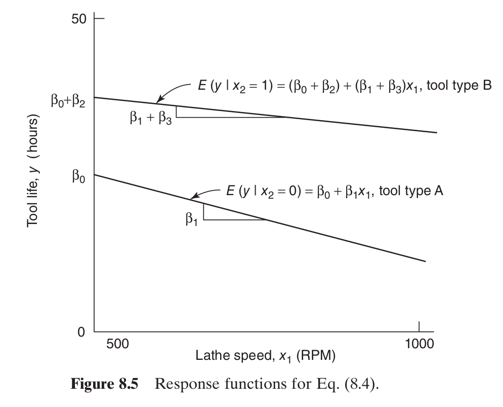

# Example

What to do

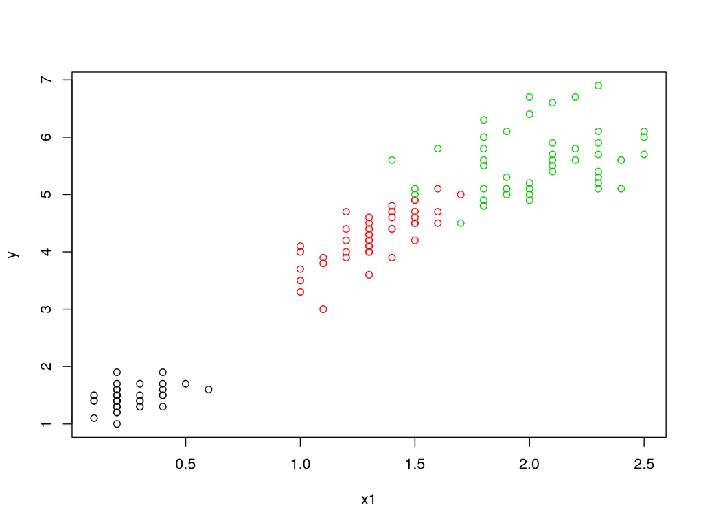

# Example

$y = \beta_0 + \beta_1x_1 + \epsilon$

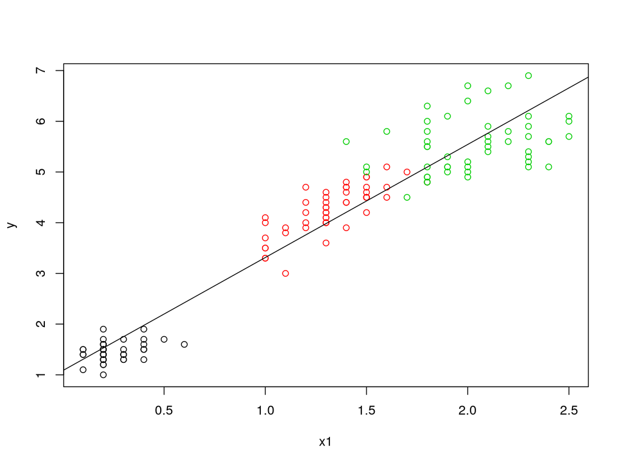

```r
mod <- lm(y ~ x1 , data = Xdf)
plot(Xdf[,2], Xdf$y, col = Xdf$Species, xlab = "x1", ylab = "y")
abline(mod)
```

# Example

$y = \beta_0 + \beta_1x_1 + \beta_2 x_2 + \beta_3 x_3 + \epsilon$

```r
mod <- lm(y ~ x1 + Species , data = Xdf)
mod
```

```
##
## Call:
## lm(formula = y ~ x1 + Species, data = Xdf)
##
## Coefficients:
##       (Intercept)                 x1  Speciesversicolor
##             1.211              1.019              1.698
##  Speciesvirginica
##             2.277
```

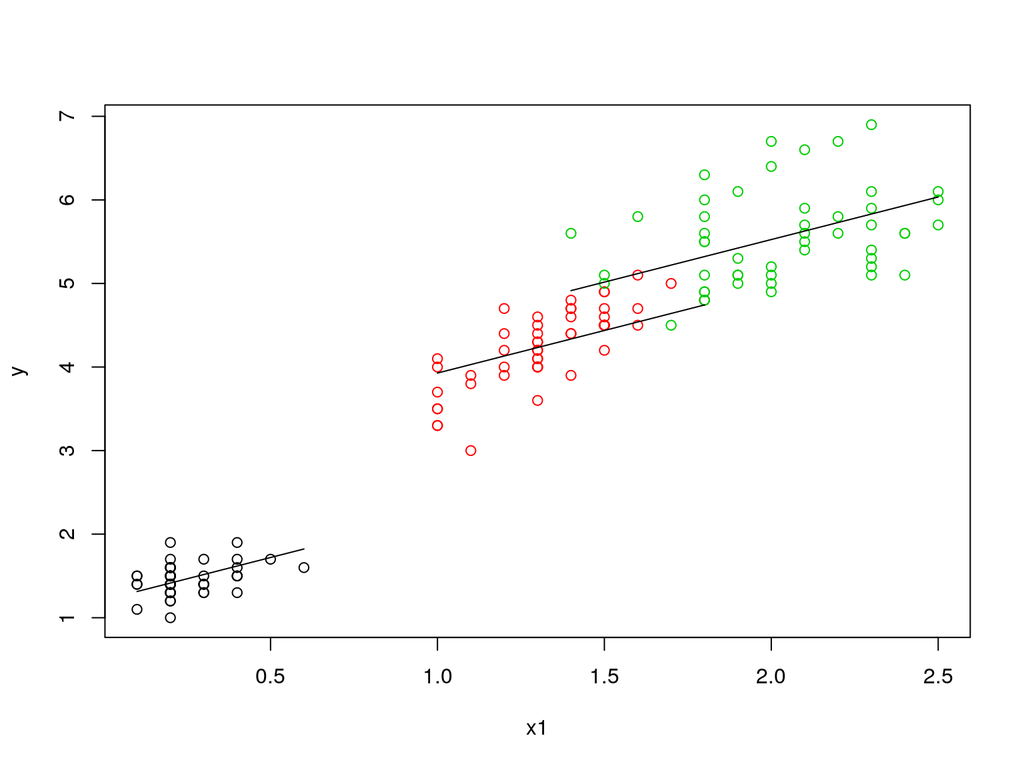

# Example

$y = \beta_0 + \beta_1x_1 + \beta_2x_2 + \beta_3 x_3 + \beta_4 x_1 x_2 + \beta_5 x_1 x_3 + \epsilon$

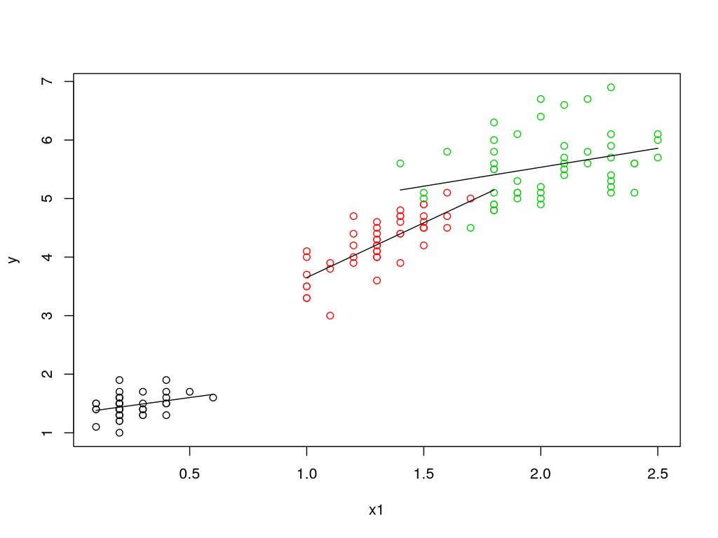

```r
plot(Xdf[,2], Xdf$y, col = Xdf$Species, xlab = "x1", ylab = "y")
fitted_vals <- predict(lm(y ~ x1 + Species + x1:Species , data = Xdf))# : means interaction
setosa_indices <- Xdf$Species == "setosa"
versicolor_indices <- Xdf$Species == "versicolor"
virginia_indices <- Xdf$Species == "virginica"
points(Xdf[setosa_indices,2], fitted_vals[setosa_indices], type = "l")
points(Xdf[versicolor_indices,2], fitted_vals[versicolor_indices], type = "l")
points(Xdf[virginia_indices,2], fitted_vals[virginia_indices], type = "l")
```

# Example

We can use our hypothesis testing chops to test $H_0: \beta_2 = \beta_3 = \beta_4 = \beta_5 = 0$

```r
lil_mod <- lm(y ~ x1 , data = Xdf)
big_mod <- lm(y ~ x1 + Species + x1:Species , data = Xdf)
anova(lil_mod, big_mod)
```

```
## Analysis of Variance Table
##
## Model 1: y ~ x1
## Model 2: y ~ x1 + Species + x1:Species
##   Res.Df    RSS Df Sum of Sq      F    Pr(>F)
## 1    148 33.845
## 2    144 18.816  4    15.029 28.755 < 2.2e-16 ***
## ---
## Signif. codes:  0 '***' 0.001 '**' 0.01 '*' 0.05 '.' 0.1 ' ' 1
```

If we didn’t reject that null, we could go on and test $H_0: \beta_4 = \beta_5 = 0$ (just intercept shifts) or $H_0: \beta_2 = \beta_3 = 0$ (just slope shifts)

# Connections with Analysis of Variance

*Analysis of variance* models are examples of regression models, usually written in a slightly different way, and are useful for analyzing data from designed experiments.

# Connections with Analysis of Variance

The *one-way fixed effects ANOVA* model is

$$y_{ij} = \mu + \tau_{i} + \epsilon_{ij}$$

- $i=1, \ldots, k$ is the treatment/factor level index
- $j = 1, \ldots, n$ is the observation index (for a particular $i$)
- $\mu$ is the overall mean
- $\sum_i \tau_i = 0$
- “one-way” refers to there being one factor (with $k$ levels)
- index notation is reminiscent of data in a “wide” (as opposed to the “long”) format

# Connections with Analysis of Variance

Is there a difference between the groups?

The main interest is in testing the hypothesis: $H_0 : \tau_1 = \cdots = \tau_k = 0$

Or in other words, is there anything going on?

# Connections with Analysis of Variance

Visually:

```r
str(InsectSprays)
```

```
## 'data.frame':    72 obs. of  2 variables:
##  $ count: num  10 7 20 14 14 12 10 23 17 20 ...
##  $ spray: Factor w/ 6 levels "A","B","C","D",..: 1 1 1 1 1 1 1 1 1 1 ...
```

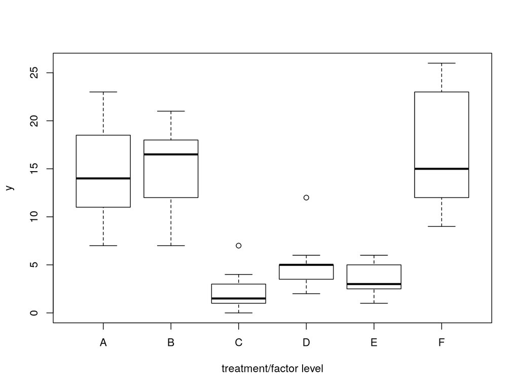

```r
boxplot(count ~ spray, data = InsectSprays,
        ylab = "y", xlab = "treatment/factor level")
```

# Connections with Analysis of Variance

Say $k=3$

$$y_{ij} = \mu + \tau_{i} + \epsilon_{ij}.$$
Then this is the same as
$$y_{ij} = \beta_0 + \beta_1 \mathbf{1}(i = 2)+ \beta_2 \mathbf{1}(i = 3) + \epsilon_{ij}$$

So

- $\mu + \tau_1 = \beta_0$
- $\mu + \tau_2 = \beta_0 + \beta_1$
- $\mu + \tau_3 = \beta_0 + \beta_2$

# Connections with Analysis of Variance

The $\sum_i \tau_i = 0$ constraint is necessary to solve this:
$$\begin{bmatrix}
1 & 1 & 0 & 0 \\
1 & 0 & 1 & 0 \\
1 & 0 & 0 & 1 \\
0 & 1 & 1 & 1
\end{bmatrix}
\begin{bmatrix}
\mu \\
\tau_1 \\
\tau_2 \\
\tau_3
\end{bmatrix} =
\begin{bmatrix}
\beta_0 \\
\beta_1 \\
\beta_2 \\
0
\end{bmatrix}$$
We get

$$\begin{bmatrix}
\mu \\
\tau_1 \\
\tau_2 \\
\tau_3
\end{bmatrix} =
\begin{bmatrix}
1/3 & 1/3 & 1/3 & -1/3 \\
2/3 & -1/3 & -1/3 & 1/3 \\
-1/3 & 2/3 & -1/3 & 1/3 \\
-1/3 & -1/3 & 2/3 & 1/3
\end{bmatrix}
\begin{bmatrix}
\beta_0 \\
\beta_1 \\
\beta_2 \\
0
\end{bmatrix}$$

# using `R`

The $F_0$ statistics are the same either way you do it

```r
summary(lm(count ~ spray, data = InsectSprays))
```

```
##
## Call:
## lm(formula = count ~ spray, data = InsectSprays)
##
## Residuals:
##    Min     1Q Median     3Q    Max
## -8.333 -1.958 -0.500  1.667  9.333
##
## Coefficients:
##             Estimate Std. Error t value Pr(>|t|)
## (Intercept)  14.5000     1.1322  12.807  < 2e-16 ***
## sprayB        0.8333     1.6011   0.520    0.604
## sprayC      -12.4167     1.6011  -7.755 7.27e-11 ***
## sprayD       -9.5833     1.6011  -5.985 9.82e-08 ***
## sprayE      -11.0000     1.6011  -6.870 2.75e-09 ***
## sprayF        2.1667     1.6011   1.353    0.181
## ---
## Signif. codes:  0 '***' 0.001 '**' 0.01 '*' 0.05 '.' 0.1 ' ' 1
##
## Residual standard error: 3.922 on 66 degrees of freedom
## Multiple R-squared:  0.7244, Adjusted R-squared:  0.7036
## F-statistic:  34.7 on 5 and 66 DF,  p-value: < 2.2e-16
```

```r
summary(aov(count ~ spray, data = InsectSprays))
```

```
##             Df Sum Sq Mean Sq F value Pr(>F)
## spray        5   2669   533.8    34.7 <2e-16 ***
## Residuals   66   1015    15.4
## ---
## Signif. codes:  0 '***' 0.001 '**' 0.01 '*' 0.05 '.' 0.1 ' ' 1
```